# Indel Signature InsDel14

# InsDel14

(corresponds to 83-type signature C_ID14)

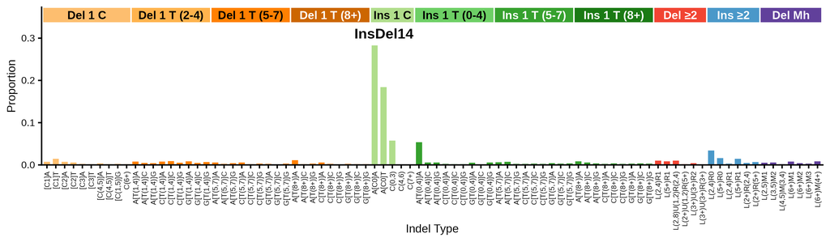

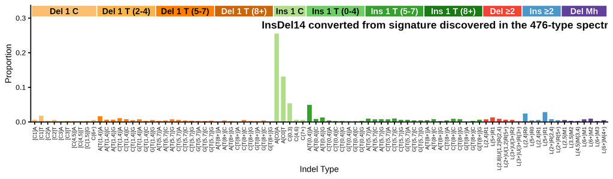

89-type spectrum of the linking tumor CPCT02340014T | cosine similarity to InsDel14: 0.9945

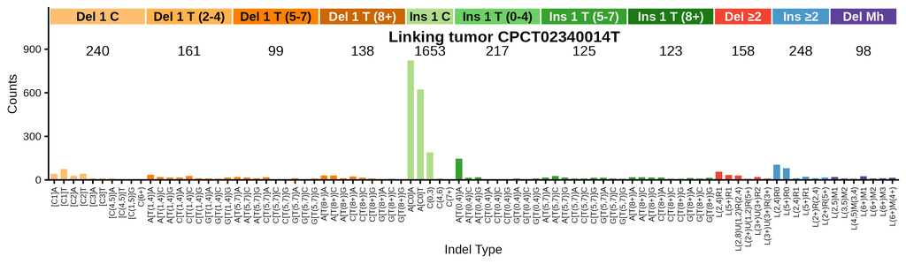

**Click to view decomposition of the linking tumor spectrum**

Partial mutation signature of CPCT02340014T due to InsDel14

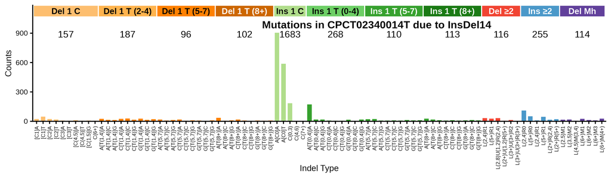

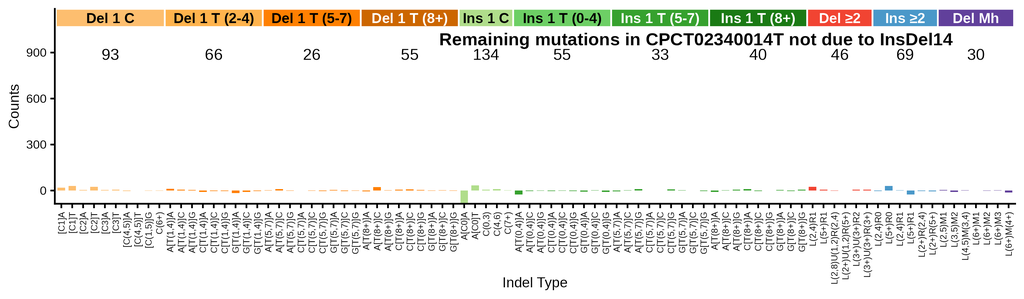

Max neg fraction (maximum allowed negative residual count as fraction of total): 0.09  
N subtract (mutation count assigned to signature): 3199.5  
N residual (mutation count in residual “partial spectrum”): 60.5  
Total negative (sum of negative residual mutation counts): 293.2  
N negative channels (number of channels with negative residual): 42  
P(≥ total negative) (Monte Carlo estimated probability that negative-binomial-sampled spectra from the signature contributing N subtract mutations would produce a total negative count >= the observed Total negative; higher number means not surprising): 0.703

**Per-channel residual breakdown**

| Channel | Spectrum | Sig_Count | Residual | Sig_Prop |
| --- | --- | --- | --- | --- |
| [Del(C):R1]A | 43 | 23.8 | 19.2 | 0.00743 |
| [Del(C):R1]T | 76 | 46.8 | 29.2 | 0.01462 |
| [Del(C):R2]A | 28 | 23.9 | 4.1 | 0.00748 |
| [Del(C):R2]T | 43 | 17.7 | 25.3 | 0.00554 |
| [Del(C):R3]A | 12 | 7.6 | 4.4 | 0.00239 |
| [Del(C):R3]T | 12 | 6.1 | 5.9 | 0.00189 |
| [Del(C):R(4,5)]A | 9 | 11.5 | -2.5 | 0.00358 |
| [Del(C):R(4,5)]T | 6 | 6.2 | -0.2 | 0.00192 |
| [Del(C):R(1,5)]G | 6 | 7.2 | -1.2 | 0.00224 |
| Del(C):R(6,9) | 5 | 5.9 | -0.9 | 0.00186 |
| A[Del(T):R(1,4)]A | 36 | 25.4 | 10.6 | 0.00794 |
| A[Del(T):R(1,4)]C | 20 | 14.7 | 5.3 | 0.00459 |
| A[Del(T):R(1,4)]G | 17 | 13.0 | 4 | 0.00407 |
| C[Del(T):R(1,4)]A | 16 | 25.8 | -9.8 | 0.00808 |
| C[Del(T):R(1,4)]C | 26 | 28.7 | -2.7 | 0.00897 |
| C[Del(T):R(1,4)]G | 12 | 16.1 | -4.1 | 0.00502 |
| G[Del(T):R(1,4)]A | 10 | 27.2 | -17.2 | 0.00851 |
| G[Del(T):R(1,4)]C | 7 | 15.2 | -8.2 | 0.00474 |
| G[Del(T):R(1,4)]G | 17 | 21.0 | -4 | 0.00655 |
| A[Del(T):R(5,7)]A | 20 | 18.6 | 1.4 | 0.00582 |
| A[Del(T):R(5,7)]C | 17 | 7.4 | 9.6 | 0.00233 |
| A[Del(T):R(5,7)]G | 12 | 13.6 | -1.6 | 0.00426 |
| C[Del(T):R(5,7)]A | 18 | 18.2 | -0.2 | 0.00569 |
| C[Del(T):R(5,7)]C | 5 | 5.8 | -0.8 | 0.00182 |
| C[Del(T):R(5,7)]G | 5 | 9.3 | -4.3 | 0.00290 |
| G[Del(T):R(5,7)]A | 12 | 8.4 | 3.6 | 0.00264 |
| G[Del(T):R(5,7)]C | 1 | 4.3 | -3.3 | 0.00134 |
| G[Del(T):R(5,7)]G | 9 | 10.1 | -1.1 | 0.00317 |
| A[Del(T):R(8,)]A | 30 | 36.1 | -6.1 | 0.01129 |
| A[Del(T):R(8,)]C | 30 | 6.9 | 23.1 | 0.00215 |

[output cut: 59 more lines]

**Click to view similar signatures from Koh et al.**

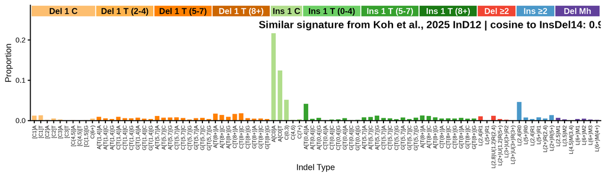

## 476-type representations corresponding to InsDel14

Extracted 476-type signature corresponding to InsDel14

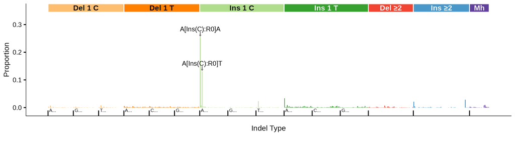

476-type spectrum of the linking tumor CPCT02340014T; cosine similarity to the extracted 476-type signature is 0.9775

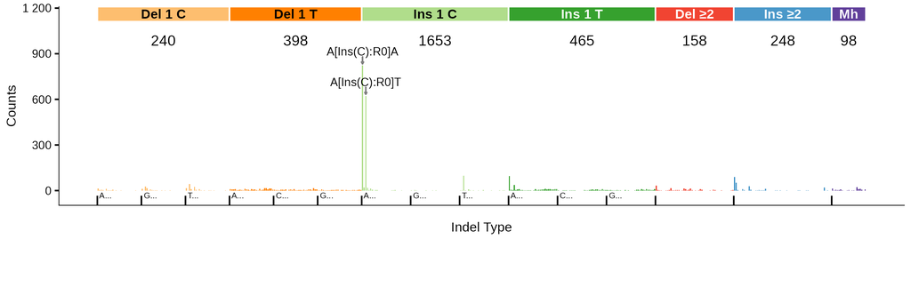

476-type spectrum of best 476-type matching tumor CPCT02050104T; cosine similarity to the extracted 476-type signature is 0.9839

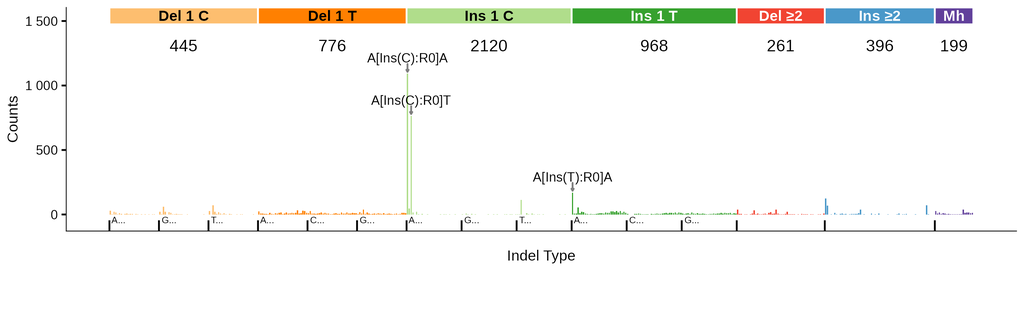

## 83-type signature corresponding to InsDel14 (C_ID14)

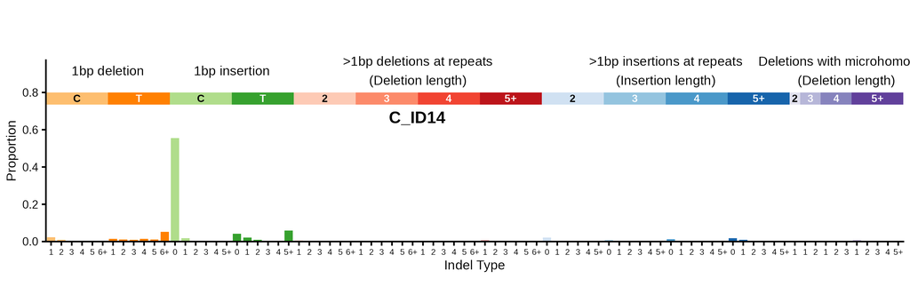

83-type signature converted from signature discovered in the 476-type spectra (using bipartite matching optimization) | cosine similarity to C_ID14: 0.9855

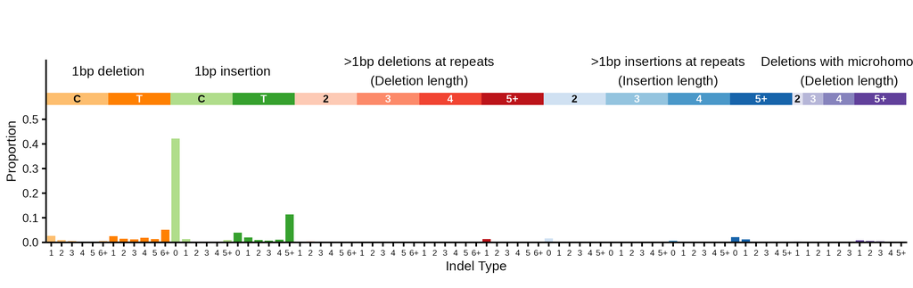

**Click to see flow diagrams: 476-type to 83-type collapse**

These Sankey diagrams show how the 476-type mutation categories are redistributed to 83-type categories using bipartite matching. We only show the diagrams for insertions or deletions of > 1 base because it is for these indels that 476-type categories map to > 1 83-type category.

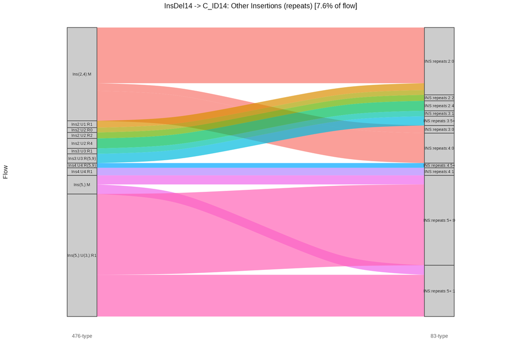

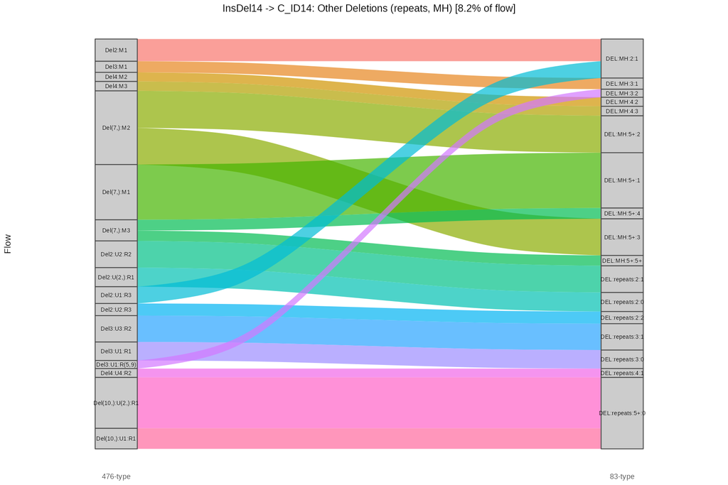

83-type spectrum of the linking tumor CPCT02340014T | cosine similarity to C_ID14: 0.9965

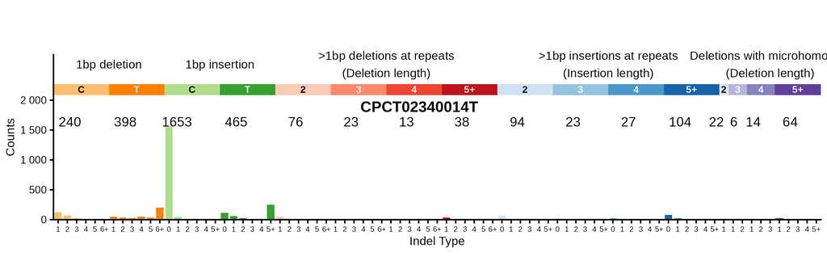

### Similar COSMIC signatures

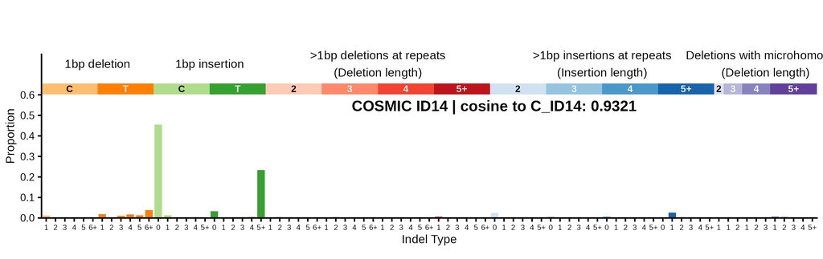

**Click here to see with insertions and deletions of T in long poly-T suppressed**

[figure not shown]

### Similar signatures from Jin et al. 2024

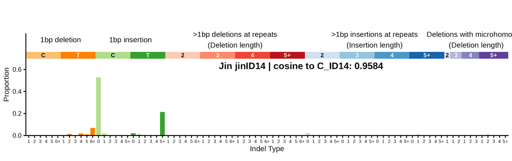

**Click here to see with insertions and deletions of T in long poly-T suppressed**

[figure not shown]